# Week_5_assignment

Salma Elshahawy

9/24/2019

# Tidying and Transforming Data

## Introduction

This week an exercise in tidying data. We’re provided untidy data in a form of csv format. The requirement is to tidy and transform it into an analyzable table where each row is a single observation and each column a single variable.

## Methodology

- We need to read the data first into R and browse the table
- Use the tidyr library to tidy the data and dplyr to transform it
- Perform analysis to compare arrival and delayed time for each air line

## Requirements

1. Create a csv file.
2. Read information from the csv file
3. Compare the arrival delays for the two airlines
4. Publish the R-Markdown file to the Rpubs

## Questions

Before starting the analysis process, we have to know what are the information we need to extract from the avaliable data. In other meaning what is the addedd business value from doing this particular analysis. For me, my questions are:

- What is the status of both delay and on-time arrivals for each air line company per state? **gives us an indicator which airline can be reliable or not**
- What is the delay rate per state?
- Can we rank the airlines per state according to total number of flights?

## Steps

Loading the necessary libraries

```r
library(tidyr)
library(dplyr)
library(stringr)
library(kableExtra)
library(ggplot2)
library(magrittr)
library(dplyr)
library(scales)
library(gganimate)
```

1. Read the csv into R

The first step is to read the data into **R**, I wrote the data on Excel file and save it as **.csv** file. After that I used the function **read.csv()** to read the data into R.

```r
library(kableExtra)
air_linetb <- read.csv("arrival_details.csv", header = TRUE, sep = ",")
air_linetb %>% kable() %>% kable_styling(bootstrap_options = c("striped", "hover", "condensed", "responsive")) %>% scroll_box(width="100%",height="300px")
```

| X | X.1 | Los.Angeles | Phoenix | San.Diego | San.Francisco | Seattle |
| --- | --- | --- | --- | --- | --- | --- |
| ALASKA | on time | 497 | 221 | 212 | 503 | 1841 |
|  | delayed | 62 | 12 | 20 | 102 | 305 |
|  |  | NA | NA | NA | NA | NA |
| AM WEST | on time | 694 | 4840 | 383 | 320 | 201 |
|  | delayed | 117 | 415 | 65 | 129 | 62 |

As illustrated in the table, the data is messy contianing **NA** rows, and double title rows. We have to clean up the data first before tidy/transform the data.

2. Remove the **NA** row and empty rows

```r
air_line_df <- as.data.frame(air_linetb)
clean_df <- air_line_df[-c(3), ]
clean_df %>% kable() %>% kable_styling(bootstrap_options = c("striped", "hover", "condensed", "responsive")) %>% scroll_box(width="100%",height="300px")
```

|  | X | X.1 | Los.Angeles | Phoenix | San.Diego | San.Francisco | Seattle |
| --- | --- | --- | --- | --- | --- | --- | --- |
| 1 | ALASKA | on time | 497 | 221 | 212 | 503 | 1841 |
| 2 |  | delayed | 62 | 12 | 20 | 102 | 305 |
| 4 | AM WEST | on time | 694 | 4840 | 383 | 320 | 201 |
| 5 |  | delayed | 117 | 415 | 65 | 129 | 62 |

3. Rename columns for (first, second) and add airline name to the empty cells in the first column

```r
# Rename columns
colnames(clean_df)[c(1,2)] <- c("air_line","status")
clean_df   %>% kable() %>% kable_styling(bootstrap_options = c("striped", "hover", "condensed", "responsive")) %>% scroll_box(width="100%",height="300px")
```

|  | air_line | status | Los.Angeles | Phoenix | San.Diego | San.Francisco | Seattle |
| --- | --- | --- | --- | --- | --- | --- | --- |
| 1 | ALASKA | on time | 497 | 221 | 212 | 503 | 1841 |
| 2 |  | delayed | 62 | 12 | 20 | 102 | 305 |
| 4 | AM WEST | on time | 694 | 4840 | 383 | 320 | 201 |
| 5 |  | delayed | 117 | 415 | 65 | 129 | 62 |

```r
# fill empty cells with the appropriate airline name
clean_df[c(2,2),1] <- "ALASKA"
clean_df[c(4,4),1] <- "AM WEST"
clean_df  %>% kable() %>% kable_styling(bootstrap_options = c("striped", "hover", "condensed", "responsive")) %>% scroll_box(width="100%",height="300px")
```

|  | air_line | status | Los.Angeles | Phoenix | San.Diego | San.Francisco | Seattle |
| --- | --- | --- | --- | --- | --- | --- | --- |
| 1 | ALASKA | on time | 497 | 221 | 212 | 503 | 1841 |
| 2 | ALASKA | delayed | 62 | 12 | 20 | 102 | 305 |
| 4 | AM WEST | on time | 694 | 4840 | 383 | 320 | 201 |
| 5 | AM WEST | delayed | 117 | 415 | 65 | 129 | 62 |

```r
clean_df
```

|  | air_line | status | Los.Angeles | Phoenix | San.Diego | San.Francisco | Seattle |
| --- | --- | --- | --- | --- | --- | --- | --- |
| 1 | ALASKA | on time | 497 | 221 | 212 | 503 | 1841 |
| 2 | ALASKA | delayed | 62 | 12 | 20 | 102 | 305 |
| 4 | AM WEST | on time | 694 | 4840 | 383 | 320 | 201 |
| 5 | AM WEST | delayed | 117 | 415 | 65 | 129 | 62 |

3. The table at this shape cannot be analyzed, we have to tidy the data first. To do so, we can use the **tidyr** package in R. We need also to transpose the table.
- We can start by generating two columns for the **City** and **Flight**

```r
str(clean_df)
```

```
## 'data.frame':    4 obs. of  7 variables:
##  $ air_line     : Factor w/ 3 levels "","ALASKA","AM WEST": 2 2 3 3
##  $ status       : Factor w/ 3 levels "","delayed","on time": 3 2 3 2
##  $ Los.Angeles  : int  497 62 694 117
##  $ Phoenix      : int  221 12 4840 415
##  $ San.Diego    : int  212 20 383 65
##  $ San.Francisco: int  503 102 320 129
##  $ Seattle      : int  1841 305 201 62
```

Using **tidyr** package we can tidy the data using the **gather()** which will create two columns for city names and flights. Here after gathering, I removed the “.” between cities’ long name

```r
gathered_df <- clean_df %>%
  gather(City, Flight, 3:7)
gathered_df$City <- str_replace(gathered_df$City, "\\.", " ")

gathered_df  %>% kable() %>% kable_styling(bootstrap_options = c("striped", "hover", "condensed", "responsive")) %>% scroll_box(width="100%",height="300px")
```

| air_line | status | City | Flight |
| --- | --- | --- | --- |
| ALASKA | on time | Los Angeles | 497 |
| ALASKA | delayed | Los Angeles | 62 |
| AM WEST | on time | Los Angeles | 694 |
| AM WEST | delayed | Los Angeles | 117 |
| ALASKA | on time | Phoenix | 221 |
| ALASKA | delayed | Phoenix | 12 |
| AM WEST | on time | Phoenix | 4840 |
| AM WEST | delayed | Phoenix | 415 |
| ALASKA | on time | San Diego | 212 |
| ALASKA | delayed | San Diego | 20 |
| AM WEST | on time | San Diego | 383 |
| AM WEST | delayed | San Diego | 65 |
| ALASKA | on time | San Francisco | 503 |
| ALASKA | delayed | San Francisco | 102 |
| AM WEST | on time | San Francisco | 320 |
| AM WEST | delayed | San Francisco | 129 |
| ALASKA | on time | Seattle | 1841 |
| ALASKA | delayed | Seattle | 305 |
| AM WEST | on time | Seattle | 201 |
| AM WEST | delayed | Seattle | 62 |

Then, **spread** the status column into two columns of delayed and on-time

```r
spread_df <- spread(gathered_df, key = "status", value = "Flight")
spread_df  %>% kable() %>% kable_styling(bootstrap_options = c("striped", "hover", "condensed", "responsive")) %>% scroll_box(width="100%",height="300px")
```

| air_line | City | delayed | on time |
| --- | --- | --- | --- |
| ALASKA | Los Angeles | 62 | 497 |
| ALASKA | Phoenix | 12 | 221 |
| ALASKA | San Diego | 20 | 212 |
| ALASKA | San Francisco | 102 | 503 |
| ALASKA | Seattle | 305 | 1841 |
| AM WEST | Los Angeles | 117 | 694 |
| AM WEST | Phoenix | 415 | 4840 |
| AM WEST | San Diego | 65 | 383 |
| AM WEST | San Francisco | 129 | 320 |
| AM WEST | Seattle | 62 | 201 |

## Analyze the data

We will get an overview of the data to explore it then will get indeep to have more insight analysis

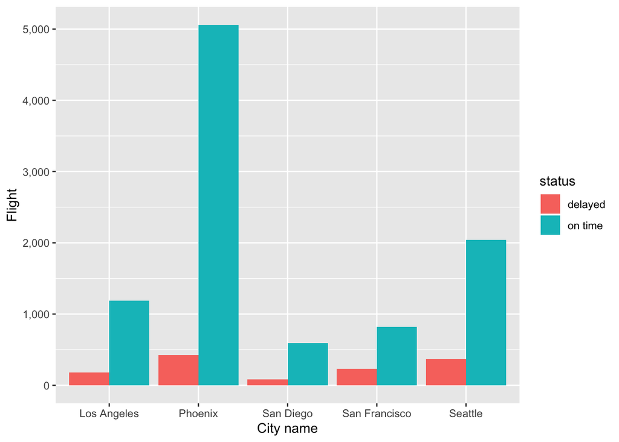

```r
by_city <- gathered_df %>%
             group_by(City, status) %>%
             summarise(Flight=sum(Flight))

ggplot(by_city, aes(x=City, y=Flight, fill=status)) +
        geom_bar(stat="identity", position=position_dodge()) +
        xlab("City name") + scale_y_continuous(labels=scales::comma) +
        scale_x_discrete()
```

We can see here that the majority of the flights status arriving **Phoenix** are on time **>5,000** flights and almost **500** delayed flights. That’s makes us more curious to know which airline has the most flights in **Phoenix**. However, let’s calculate the delay rate per state first.

To calculate the delay rate, I summarize the sum of the delayed time devided on sum of the number of on-time flights inside the aggrigation function **group_by**

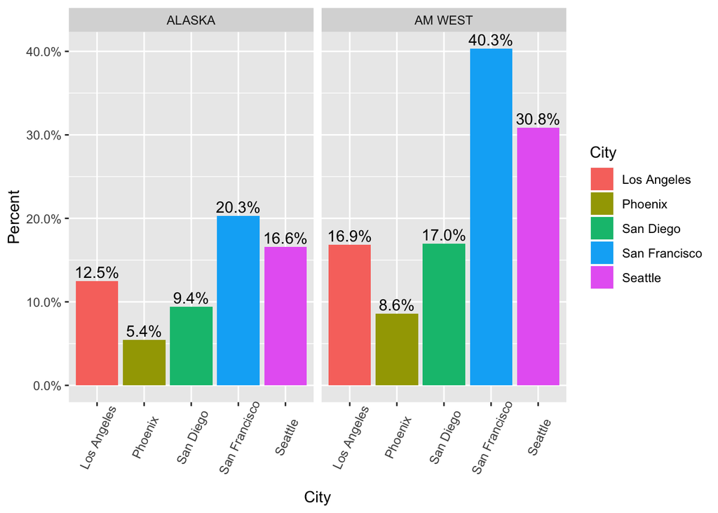

```r
delay_rate <- spread_df %>%
                 group_by(air_line, City) %>%
                 summarise(delay.rate = sum(delayed)/sum(`on time`))

ggplot(delay_rate, aes(x = City, y = delay.rate,fill = City)) +
     geom_bar(stat="identity") +
     geom_text(aes( label = scales::percent(delay.rate),
                   y= delay.rate ), stat= "identity", vjust = -.3) +
     labs(y = "Percent", fill="City") +
     facet_grid( ~ air_line) +
     scale_y_continuous(labels = scales::percent) +
     theme(axis.text.x = element_text(angle=65, vjust=0.65))
```

It seems that **AM WEST** has more delays rate especially for **San Franscisco** and **Seattle** with **40.3% and 30.8%** respectively compared to **ALASKA** which has almost **half** these rates.

Then we have to get the total flights per state

```r
total_flights <- mutate(spread_df, total_num = delayed + `on time`)
total_flights %>% kable() %>% kable_styling(bootstrap_options = c("striped", "hover", "condensed", "responsive")) %>% scroll_box(width="100%",height="300px")
```

| air_line | City | delayed | on time | total_num |
| --- | --- | --- | --- | --- |
| ALASKA | Los Angeles | 62 | 497 | 559 |
| ALASKA | Phoenix | 12 | 221 | 233 |
| ALASKA | San Diego | 20 | 212 | 232 |
| ALASKA | San Francisco | 102 | 503 | 605 |
| ALASKA | Seattle | 305 | 1841 | 2146 |
| AM WEST | Los Angeles | 117 | 694 | 811 |
| AM WEST | Phoenix | 415 | 4840 | 5255 |
| AM WEST | San Diego | 65 | 383 | 448 |
| AM WEST | San Francisco | 129 | 320 | 449 |
| AM WEST | Seattle | 62 | 201 | 263 |

After that, get the highest number per airline company

```r
# get mean first then get the total number of flights that is bigger than this number
highest_num <- total_flights %>%
  select(air_line, City, total_num) %>%
  filter(total_num > mean(total_flights$total_num)) %>%
  arrange(desc(total_num))
highest_num %>% kable() %>% kable_styling(bootstrap_options = c("striped", "hover", "condensed", "responsive")) %>% scroll_box(width="100%",height="300px")
```

| air_line | City | total_num |
| --- | --- | --- |
| AM WEST | Phoenix | 5255 |
| ALASKA | Seattle | 2146 |

It seams that **AM WEST** is domenating in **Phoenix** while **ALASKA** is in **Seattle**. This comparasion should be clear if we create a ranking system to rank air-lines in each state

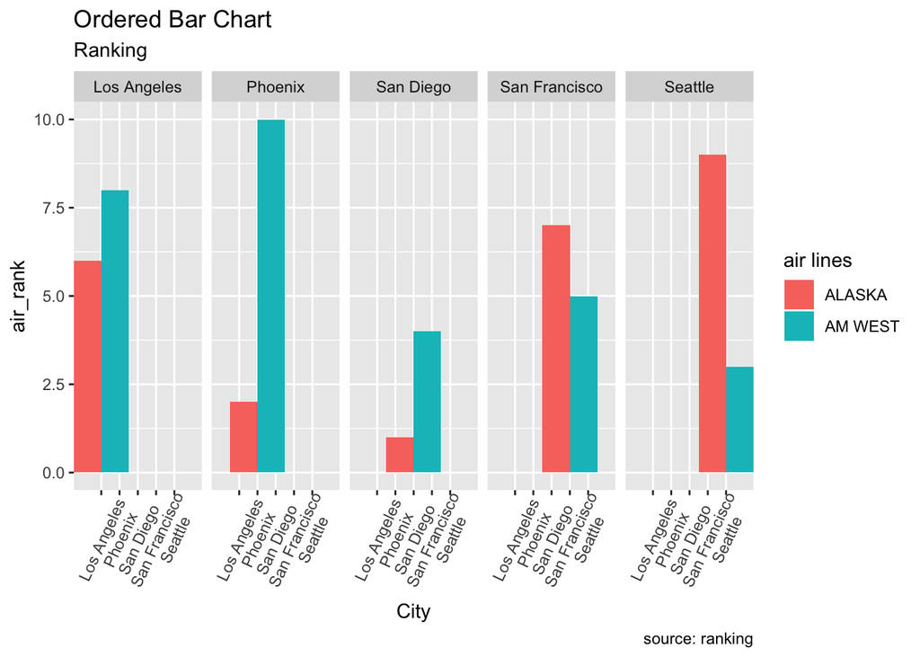

```r
ranking <- total_flights %>%
  mutate(air_rank = dense_rank(total_num)) %>%
  select(air_line, City, total_num, air_rank) %>%
  arrange((air_rank))
# Draw plot

ggplot(ranking, aes(x=City, y=air_rank, fill = air_line)) +
  geom_bar(stat="identity", width=3, position = position_dodge()) +
  labs(fill="air lines") +
  labs(title="Ordered Bar Chart",
       subtitle="Ranking",
       caption="source: ranking") +
  theme(axis.text.x = element_text(angle=65, vjust=0.6)) +
  facet_grid( ~ City)
```

From all the previous analysis, we may conclude that **AM WEST** is the best company in **Phoenix**; however, **ALASKA** is the best on **Seattle** based on the total number of flights.

## Important links

GitHub : [GitHub link](https://github.com/salma71/MSDS_2019/blob/master/Fall2019/aquisition%26management_607/week_5/week_5_607.Rmd)

csv file: [CSV](https://github.com/salma71/MSDS_2019/blob/master/Fall2019/aquisition%26management_607/week_5/arrival_details.csv)